# Toolbox

Matti Vuorre

January 1, 2016

# The psychologist's data toolbox 2.0

Many introductory statistics and research methods courses in psychology teach a particular workflow for moving from raw data to figures and statistical tests. This workflow heavily depends on two commercial tools: Microsoft Excel and IBM SPSS. Students of these courses are instructed to perform basic data manipulation tasks, such as renaming variables, aggregating data ("pivot tables"), subsetting data, etc., in Excel before proceeding to create figures (in Excel or SPSS) and perform statistical inference (usually in SPSS.)

Based on my experience, this workflow is also common among researchers. Although skilled analysts can and do perfrom brilliantly when constrained by this basic recipe, better alternatives have, unsurprisingly, sprung up in the past two decades. In this document, I propose that by abandoning this Excel -> SPSS (repeated *ad nauseam* with slight tweaks that require many a buttons to be repeatedly clicked) workflow, students and researchers gain a better understanding of their data, and become better equipped to rapidly investigate their data from multiple angles. Specifically, I'll introduce the basics of the R programming language, with its stellar repertoire of user-contributed packages to perfrom various data "wrangling" and plotting operations. For an in-depth analysis of how R has totally overtaken SPSS on almost any metric, see [this post](http://r4stats.com/articles/popularity/).

Because the initial data wrangling often needs to be repeated multiple times, the task can be greatly sped up by eschewing the use of Excel in favor of a programming language, where changing a few variables does what requires a completely new walk-through of the data in Excel. Similarly, because figures need to be repeatedly generated, creating them in a programmatic manner greatly reduces the required time for this step of a data-analytic workflow.

Because my goal is to introduce R to *practitioners* of statistical analyses, I will not cover the basics of R in a conventional sense, where we create vectors of numbers and multiply them by 1, but instead we focus on multiple **"scenarios"** that practicing psychologists may encounter. Through these scenarios, we become familiar with *awesome* tools that are applicable in any domain, and the switch from an example scenario to the one you are facing right now requires only a slight rethinking in data organization and variable names.

# Before we get started...

Programming is hard. You learn it by doing it. I recommend you follow the examples here by typing them into your own R script files, and execute them on your own computer. No prior knowledge of R or programming in general is required, but I will not explain, for example, how to create folders on your computer.

I rely heavily on user-contributed packages to the R programming language, but many people still hold to the maxim that "unnecessary abstraction" is evil: They claim that we should be using base-R functions, instead of additional packages, to perform computation in R. I think they are flat-out wrong. In this tutorial, I make an analogy to DIY: The 2.0 data toolbox consists of a toolshed (R and RStudio) containing a set of tools (additional packages), instead of just a hammer and a chisel (base-R, or only pre-built functions in the R programming language.) Note that I do not claim that base-R doesn't do its job, it does it brilliantly, in fact, but we can learn much faster, and generalize the skills much easier by using additional packages, and that is my goal.

We will dive right into our first scenario: Questionnaire data

# Scenario 1: Personality Questionnaire Data

## Section 1.1

In the first part of this scenario, we'll download an open personality questionnaire data set, and learn to

- organize a programming project
- get started with RStudio
- install R packages
- load data with RStudio
  - New tool: The `read_` family of functions
- look at the data
- recode variables
  - New tool: `mutate()`

As a bonus, we will immediately start learning good programming practices by making our code (and data) **human-readable**.

Our goal is to produce analyses that we can re-run with minimum effort. The first step toward this goal is to create and maintain a clear organization for our materials. Therefore, we'll spend the first 3 minutes reflecting on how the project should be organized.

### Project organization

A typical project consists of source data files, analysis script(s), and output files, such as figures, tables, and possibly manuscripts. Realizing that these basic components need to be stored in an understandable and accessible manner, we create a **folder structure** accordingly:

```
toolbox/
|-- scenario1/
|    |-- data/
|        |-- data.csv
|    |-- analysis/
|    |-- output/
```

### Download the data

This data set is available [here](http://personality-testing.info/_rawdata/BIG5.zip)[^1]. Go ahead and download the .zip file, and unzip it into your data directory.

### Open RStudio

Now that you've your materials in your shiny new toolshed, it's time to step in and get to work. Open RStudio, navigate to `toolbox/analysis/` and set it as your working directory:

[figure not shown]

Now we're prepared to start writing commands, but before we do so, we want to create a file where we can save these commands. This file is an R script, and when we're done writing all our commands, we can re-run the whole analysis by simply sourcing it! No need to point-and-click your way through multiple menus.

[figure not shown]

### Install packages

As I explained above, we will rely on additional packages to the R programming language. Installing these packages is simple; you only need to call a few functions in R. So, with R open, enter the following commands to the console:

```r
install.packages("dplyr")
install.packages("ggplot2")
install.packages("reshape2")
```

We are now ready to begin...

### Load the data

We downloaded a *tab-separated* spreadsheet of data, meaning that each column in the data-set is separated by a tab. I encounter *comma-separated* tables more often, but the separator doesn't matter! It's just good to know what your source is. Let's enter the first line of code to our script: Load the data. As I alluded to above, by knowing your source, you know right away which tool to grab. Here, we will use the `read_tsv` function (=tool) from the `readr` package.

```r
library(readr)  # Loads the readr package
d <- read_tsv("../data/data.csv")
d <- na.omit(d)  # Remove all missing values
```

For an explanation of the `"../data/data.csv"` argument to the function, refer to the folder structure defined above. We only need to tell `read_tsv()` where the file is, and it takes care of the rest. Because we are operating in `toolbox/analysis/` we need to refer one folder down in the hierarchy (`"../"`) and then one up to `"data/"` to access `data.csv`. Do **not** set working directories in your script, because these calls make others with different root folder structures (usernames, systems, etc.) unable to run your script without changing these arguments.

We also removed the missing data right away (not many lines), and accept that this is an advanced topic.

### Get to know the data

Usually at this stage you would probably already know quite a bit about the data, if you collected it yourself. Here we get familiar with the data for this example: The data consist of responses to the Big Five personality questionnaire, and we have indicator variables for the country, age, sex, race, etc. of the respondent. Plenty to explore!

> This data was collected (c. 2012) through on interactive online personality test. Participants were informed that their responses would be recorded and used for research at the begining of the test and asked to confirm their consent at the end of the test.[^2]

The structure of the data is as follows:

```r
d  # We can inspect the data_frame by simply calling our object d
```

```r
# Source: local data frame [19,710 x 57]
#
#     race   age engnat gender  hand source country    E1    E2    E3    E4
#    (int) (int)  (int)  (int) (int)  (int)   (chr) (int) (int) (int) (int)
# 1      3    53      1      1     1      1      US     4     2     5     2
# 2     13    46      1      2     1      1      US     2     2     3     3
# 3      1    14      2      2     1      1      PK     5     1     1     4
# 4      3    19      2      2     1      1      RO     2     5     2     4
# 5     11    25      2      2     1      2      US     3     1     3     3
# 6     13    31      1      2     1      2      US     1     5     2     4
# 7      5    20      1      2     1      5      US     5     1     5     1
# 8      4    23      2      1     1      2      IN     4     3     5     3
# 9      5    39      1      2     3      4      US     3     1     5     1
# 10     3    18      1      2     1      5      US     1     4     2     5
# ..   ...   ...    ...    ...   ...    ...     ...   ...   ...   ...   ...
# Variables not shown: E5 (int), E6 (int), E7 (int), E8 (int), E9 (int), E10
#   (int), N1 (int), N2 (int), N3 (int), N4 (int), N5 (int), N6 (int), N7
#   (int), N8 (int), N9 (int), N10 (int), A1 (int), A2 (int), A3 (int), A4
#   (int), A5 (int), A6 (int), A7 (int), A8 (int), A9 (int), A10 (int), C1
#   (int), C2 (int), C3 (int), C4 (int), C5 (int), C6 (int), C7 (int), C8
#   (int), C9 (int), C10 (int), O1 (int), O2 (int), O3 (int), O4 (int), O5
#   (int), O6 (int), O7 (int), O8 (int), O9 (int), O10 (int)
```

We have a `data_frame` named `d` that contains 19710 observations on 57 variables: Each variable is contained in a column, with the top entry (`race`, `age`, ...) giving names to the variables. Under the name in parenthesis, we see the data type of each variable: integers and characters.

**Note to readers who already use R**: A data_frame is slightly different, but arguably better, than the base-R data.frame. For instance, note how the object printed in the console: We see each variable and its associated data type, and additional lines are automatically clipped. We can, however, conceptually treat it as a data.frame for almost any application.

### Recode variables

Here we encounter the first of many perils of not organizing and curating your materials well: Although we know what race means (maybe?), the numbers don't make any sense. What is race 13? The authors of course have provided a codebook (it's now in your `toolbox/data/` folder), but such an external file requires us to switch back and forth between files to understand our data, and I strongly recommend writing **human-readable** variable names and code so that we don't need to go back and forth between the data and its related codebook. The first step, therefore, is to make the data as close to human-readable as possible.

For this task, we'll pick up another tool: the `mutate()` function in the `dplyr` package.

The following code takes `d` and converts `race`, `engnat`, `gender`, and `hand` into more readable **factors**. Factors are R's way of attaching verbal labels to numerical data, and are the suitable data format for these variables.

```r
library(dplyr)
d <- mutate(
    d,
    # Change race into a factor with the following verbal labels
    race = factor(race,
                  labels = c("no_response",
                             "mixed_race",
                             "arctic",
                             "caucasian_european",
                             "caucasian_indian",
                             "caucasian_middle_east",
                             "caucasian_n_africa_other",
                             "indigenous_australian",
                             "native_american",
                             "north_east_asian",
                             "pacific",
                             "south_east_asian",
                             "west_african",
                             "other")),
    # Ditto for English as native language
    engnat = factor(engnat,
                    labels = c("no_response", "yes", "no")),
    # ...Gender...
    gender = factor(gender,
                    labels = c("no_response", "male", "female", "other")),
    # ...And handedness
    hand = factor(hand,
                  labels = c("no_response", "right", "left", "both"))
)
```

Before we view the output, let's reflect on what we just did. We took `d` and passed it as the first argument to `mutate()`. `mutate()` is a powerful function from the `dplyr` package that takes a data frame as input, and creates new variables within that data frame. We overwrote the original variables by calls to `factor()`, that simply converts the old variable, for example `race`, by a new one that took the numerical values of `race` and attached them with verbal labels.

Let's see what we ended up with:

```r
d
```

```r
# Source: local data frame [19,710 x 57]
#
#                     race   age engnat gender   hand source country    E1
#                   (fctr) (int) (fctr) (fctr) (fctr)  (int)   (chr) (int)
# 1     caucasian_european    53    yes   male  right      1      US     4
# 2                  other    46    yes female  right      1      US     2
# 3             mixed_race    14     no female  right      1      PK     5
# 4     caucasian_european    19     no female  right      1      RO     2
# 5       south_east_asian    25     no female  right      2      US     3
# 6                  other    31    yes female  right      2      US     1
# 7  caucasian_middle_east    20    yes female  right      5      US     5
# 8       caucasian_indian    23     no   male  right      2      IN     4
# 9  caucasian_middle_east    39    yes female   both      4      US     3
# 10    caucasian_european    18    yes female  right      5      US     1
# ..                   ...   ...    ...    ...    ...    ...     ...   ...
# Variables not shown: E2 (int), E3 (int), E4 (int), E5 (int), E6 (int), E7
#   (int), E8 (int), E9 (int), E10 (int), N1 (int), N2 (int), N3 (int), N4
#   (int), N5 (int), N6 (int), N7 (int), N8 (int), N9 (int), N10 (int), A1
#   (int), A2 (int), A3 (int), A4 (int), A5 (int), A6 (int), A7 (int), A8
#   (int), A9 (int), A10 (int), C1 (int), C2 (int), C3 (int), C4 (int), C5
#   (int), C6 (int), C7 (int), C8 (int), C9 (int), C10 (int), O1 (int), O2
#   (int), O3 (int), O4 (int), O5 (int), O6 (int), O7 (int), O8 (int), O9
#   (int), O10 (int)
```

Much better! Now we can immediately see meaningful values of race, gender, etc.

#### In-depth: `mutate()`

To understand what `mutate()` does, let's focus on a very simple example. We'll create a data frame with two variables, and use `mutate()` to create new variables within the data frame.

```r
tmnt <- data_frame(var_a = 1:10,  # Integers from 1 to 10
                   pi = 3.14159)

tmnt <- mutate(tmnt,
               multiples_of_pi = round(var_a * pi, 2))
tmnt
```

```r
# Source: local data frame [10 x 3]
#
#    var_a      pi multiples_of_pi
#    (int)   (dbl)           (dbl)
# 1      1 3.14159            3.14
# 2      2 3.14159            6.28
# 3      3 3.14159            9.42
# 4      4 3.14159           12.57
# 5      5 3.14159           15.71
# 6      6 3.14159           18.85
# 7      7 3.14159           21.99
# 8      8 3.14159           25.13
# 9      9 3.14159           28.27
# 10    10 3.14159           31.42
```

Later, we will be repeatedly calling `mutate()` with different functions inside it. It's true power will be revealed once we learn a few more functions from `dplyr`, and link them together for powerful data wrangling.

### Summary of section 1.1

We entered our toolshed (RStudio) and prepared our workspace. We then learned about `readr` for reading data, and `dplyr` (particularly its `mutate()` function.) By using these tools, we wrangled our data a little bit: We moved from a non-human readable data file to something that looks interpretable by a human. In the next section, we will take `dplyr` to its proper use and group and summarise the data in various ways.

## Intermission

This is taking a while! Are you still following? Let's take a step back and think about what the goal here is: We want to understand the data in front of us. In order to accomplish this, we must know how to effectively wrangle the data; to group it in various ways, to aggregate it at multiple levels of different grouping factors. We want to be able to quickly draw figures like the two I'll show below:

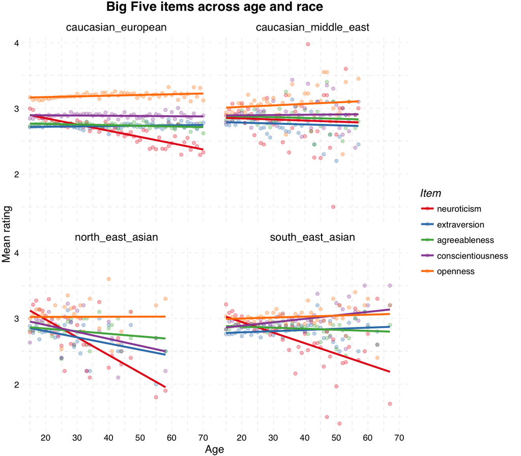

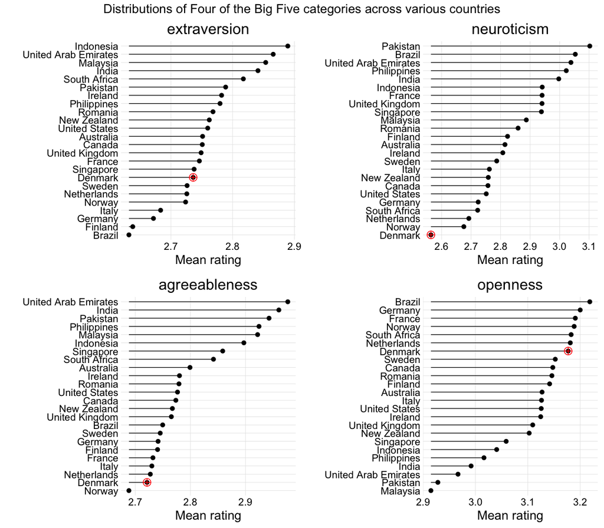

Look at those Danes, with their high openness and low neuroticism... These figures took me about 10 minutes to make. But if I want to change something in them (aesthetics, grouping variables, exclude or include more data, manipulations...), it will take me about 20 seconds and the plots are redrawn with the desired changes. Do that in SPSS or Excel! And this is the point, we want to be able to *quickly* investigate our data from multiple angles. We'll learn just that in the next section.

## Section 1.2

We now have an understandable data frame in R, and we can begin investigating it. We will ask simple questions and learn to translate them into R code, holding our tools close to hand at all times. We'll

- summarise variables at different levels of other variables
  - new tools: `group_by()` and `summarise()`
  - draw our first plot
    - new tool: `ggplot()`
- subset and filter the data
  - new tools: `select()` and `filter()`

Again, there's a bonus! You'll learn perhaps the most powerful operator in R: The "then do this" operator, or **pipe**.

### The pipe

When I first encountered the pipe, I was perplexed. What is this messy looking thing on each line? I quickly learned that the pipe connects commands and makes the code much more readable by humans. Here's what it looks like: `%>%`. Simple as that. By appending that to the end of a line, we can pipe commands without either nesting commands, or saving intermediate output. This makes a huge difference. In this section, we will put the pipe into use right away.

There will be a lot of material here, but you can take as long as you wish. If at this stage you haven't done so, I strongly recommend following along by writing the commands to your own R script, and executing them on your own computer.

### Summarise variables

This is a common scenario in questionnaire research: We are not necessarily as interested in individual items on a questionnaire, but rather in the subsets they form. We know that we have five categories of questionnaire items in the Big Five, so here we will create, for each individual respondent, mean values of each of the Big Five categories.

```r
d <- d %>%
    add_rownames("id") %>%
    group_by(id) %>%
    mutate(extraversion = mean(c(E1, E2, E3, E4, E5, E6, E7, E8, E9, E10)))
```

Let me read that aloud for you (Read the `%>%` as simply saying "then..."):

> Save into `d` the following: Take `d`, *then* add row names and call them `id` (each row is one person's data). *Then* group the data by `id`, and *then* for each group (specified by `group_by()`), `mutate()` a new variable by taking the mean of all "E" items.

All those "then" statements perhaps make the english suboptimal, but bear with me. This code reads like a beautiful cyberpunk novel.

We now have a data frame with our desired (by-person) summaries for each Big Five category. But we are interested in "summaries of summaries", or how these Big Five categories can be summarised for each country, gender, age, etc. So we turn to our next tool: `summarise()`. Don't worry, if you prefer to write things with a z, the creator of this package has you covered, you can write `summarize()` instead.

### First plot

Let's simply ask for summaries of all of the Big Five categories across `race`. Notice that we are not saving the output of these operations at any point, but simply pipe commands together and view the output in the console. But often that's not enough, we would like to **see** the data. At the end of this command pipe-line, we feed the output to `ggplot()` and view the results graphically. There will be many new commands in here, but keep smashing your keyboard and enlightenment will follow.

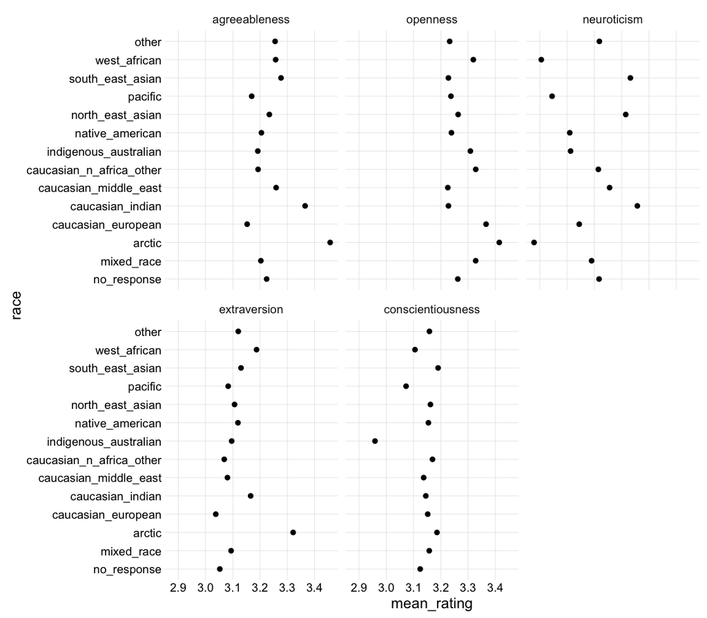

```r
d %>%
    # Group d by race
    group_by(race) %>%
    # Compute means of each Big Five for each grouping variable
    summarise(agreeableness = mean(agreeableness),
              openness = mean(openness),
              neuroticism = mean(neuroticism),
              extraversion = mean(extraversion),
              conscientiousness = mean(conscientiousness)) %>%
    # Melt into long format suitable for plotting
    melt(variable.name = "Item", value.name = "mean_rating") %>%
    # Plot it already!
    ggplot(aes(x = race, y = mean_rating)) +
    geom_point() +
    coord_flip() +
    facet_wrap(~Item)
```

Great! We let the plotting function `ggplot()` automatically take care of some of the subsetting we wanted to do. This is an extremely powerful feature of `ggplot()` and will feature heavily in the section dedicated to `ggplot()`. For now, we want to keep using `dplyr` verbs to subset our data.

### Subsets and filters

Our first operation will be to subset our data frame `d` by removing all the raw questionnaire items. We subset data frames by using the `select()` command.

```r
d <- select(d,
            -starts_with("E", ignore.case=F),
            -starts_with("O", ignore.case=F),
            -starts_with("N", ignore.case=F),
            -starts_with("C", ignore.case=F),
            -starts_with("A", ignore.case=F))
d
```

```r
# Source: local data frame [19,710 x 13]
#
#       id                  race   age engnat gender   hand source country
#    (chr)                (fctr) (int) (fctr) (fctr) (fctr)  (int)   (chr)
# 1      1    caucasian_european    53    yes   male  right      1      US
# 2      2                 other    46    yes female  right      1      US
# 3      3            mixed_race    14     no female  right      1      PK
# 4      4    caucasian_european    19     no female  right      1      RO
# 5      5      south_east_asian    25     no female  right      2      US
# 6      6                 other    31    yes female  right      2      US
# 7      7 caucasian_middle_east    20    yes female  right      5      US
# 8      8      caucasian_indian    23     no   male  right      2      IN
# 9      9 caucasian_middle_east    39    yes female   both      4      US
# 10    10    caucasian_european    18    yes female  right      5      US
# ..   ...                   ...   ...    ...    ...    ...    ...     ...
# Variables not shown: extraversion (dbl), openness (dbl), agreeableness
#   (dbl), neuroticism (dbl), conscientiousness (dbl)
```

Don't worry about the details of this command right now, but appreciate that it is rather readable: select variables in `d` that start with either of the capital letters specified below. The negation before each line says that these should, in fact, be negatively selected (i.e. dropped.)

[^1]: http://personality-testing.info/_rawdata/